# Getting started with Negative Binomial Regression Modeling

This rmarkdown notebook follows the same analysis as in the following link, but in a more tidyverse-fashion:

https://data.library.virginia.edu/getting-started-with-negative-binomial-regression-modeling/

```r
library(tidyverse)
library(MASS)
```

The following data is from “Categorial Data Analysis”, by Alan Agresti (2002) in Table 13.6 in section 13.4.3. The data are from a survey of 1308 people in which they were asked how many homicide victims they know.

```r
black <- c(119,16,12,7,3,2,0)
white <- c(1070,60,14,4,0,0,1)
resp <- c(rep(0:6,times=black), rep(0:6,times=white))
race <- factor(c(rep("black", sum(black)), rep("white", sum(white))), levels = c("white","black"))
victim <- tibble(resp, race)
```

First, notice most respondents are white.

```r
victim %>% group_by(race) %>% summarise(count=n())
```

```
## # A tibble: 2 x 2
##   race  count
##   <fct> <int>
## 1 white  1149
## 2 black   159
```

Blacks have a higher mean count than whites.

```r
victim %>% group_by(race) %>% summarise(mean=mean(resp))
```

```
## # A tibble: 2 x 2
##   race    mean
##   <fct>  <dbl>
## 1 white 0.0923
## 2 black 0.522
```

For each race, the sample variance is roughly double the mean; it appears we have overdispersion.

```r
victim %>% group_by(race) %>% summarise(variance=var(resp))
```

```
## # A tibble: 2 x 2
##   race  variance
##   <fct>    <dbl>
## 1 white    0.155
## 2 black    1.15
```

Take one look at the distribution of counts by race.

```r
victim %>% group_by(resp,race) %>% summarise(count = n()) %>% spread(key=race, value=count)
```

```
## # A tibble: 7 x 3
## # Groups:   resp [7]
##    resp white black
##   <int> <int> <int>
## 1     0  1070   119
## 2     1    60    16
## 3     2    14    12
## 4     3     4     7
## 5     4    NA     3
## 6     5    NA     2
## 7     6     1    NA
```

Try a Poisson regression.

```r
pGLM <- glm(resp ~ race, data=victim, family = poisson)
summary(pGLM)
```

```
##
## Call:
## glm(formula = resp ~ race, family = poisson, data = victim)
##
## Deviance Residuals:
##     Min       1Q   Median       3Q      Max
## -1.0218  -0.4295  -0.4295  -0.4295   6.1874
##
## Coefficients:
##             Estimate Std. Error z value Pr(>|z|)
## (Intercept) -2.38321    0.09713  -24.54   <2e-16 ***
## raceblack    1.73314    0.14657   11.82   <2e-16 ***
## ---
## Signif. codes:  0 '***' 0.001 '**' 0.01 '*' 0.05 '.' 0.1 ' ' 1
##
## (Dispersion parameter for poisson family taken to be 1)
##
##     Null deviance: 962.80  on 1307  degrees of freedom
## Residual deviance: 844.71  on 1306  degrees of freedom
## AIC: 1122
##
## Number of Fisher Scoring iterations: 6
```

The coefficient 1.73 is the one and only dichotomous predictor. It is the difference in log expected counts.

```r
coef(pGLM)
```

```
## (Intercept)   raceblack
##   -2.383208    1.733145
```

```r
victim %>% group_by(race) %>% summarise(log_mean=log(mean(resp)))
```

```
## # A tibble: 2 x 2
##   race  log_mean
##   <fct>    <dbl>
## 1 white   -2.38
## 2 black   -0.650
```

We expect to get the sample means when we make a prediction with this model and exponentiate the results.

```r
poismeans <- predict(pGLM, newdata = tibble(race=c("white","black"))) %>% exp()
poismeans
```

```
##          1          2
## 0.09225413 0.52201258
```

This says the count of known victims for whites is distributed as Poisson with mean=variance=0.09, and for blacks is distributed as Poisson with mean=variance=0.52. This is not pleasing as we knew a prior that the variance is about twice as much as the mean.

Let’s see how bad this is.

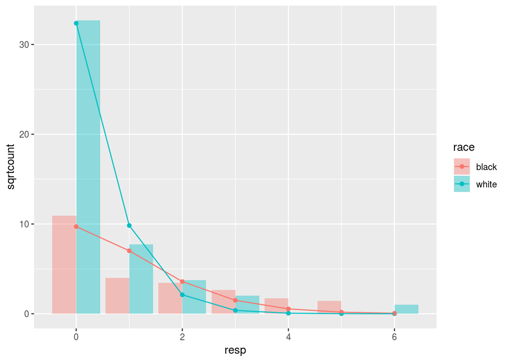

```r
poisW <- dpois(0:6,lambda = poismeans[1]) * sum(victim$race=="white")
poisB <- dpois(0:6,lambda = poismeans[2]) * sum(victim$race=="black")
poisTidy <- tibble(
  resp=rep(0:6,4),
  obs=factor(rep(c(rep("observed",7),rep("fitted",7)),2)),
  race=factor(c(rep("white",14),rep("black",14))),
  count=c(white,poisW,black,poisB)) %>%
  mutate(sqrtcount=sqrt(count))
poisTidy %>% ggplot(aes(x=resp,y=sqrtcount)) +
  geom_col(data=subset(poisTidy, obs=='observed'), aes(fill=race), position = "dodge", alpha=0.4) +
  geom_point(data=subset(poisTidy, obs=='fitted'), aes(colour=race)) +
  geom_line(data=subset(poisTidy, obs=='fitted'), aes(colour=race))
```

Let’s run a negative binomial model instead. As expected, we get the same coefficients as before.

```r
nbGLM <- glm.nb(resp ~ race, data=victim)
summary(nbGLM)
```

```
##
## Call:
## glm.nb(formula = resp ~ race, data = victim, init.theta = 0.2023119205,
##     link = log)
##
## Deviance Residuals:
##     Min       1Q   Median       3Q      Max
## -0.7184  -0.3899  -0.3899  -0.3899   3.5072
##
## Coefficients:
##             Estimate Std. Error z value Pr(>|z|)
## (Intercept)  -2.3832     0.1172 -20.335  < 2e-16 ***
## raceblack     1.7331     0.2385   7.268 3.66e-13 ***
## ---
## Signif. codes:  0 '***' 0.001 '**' 0.01 '*' 0.05 '.' 0.1 ' ' 1
##
## (Dispersion parameter for Negative Binomial(0.2023) family taken to be 1)
##
##     Null deviance: 471.57  on 1307  degrees of freedom
## Residual deviance: 412.60  on 1306  degrees of freedom
## AIC: 1001.8
##
## Number of Fisher Scoring iterations: 1
##
##
##               Theta:  0.2023
##           Std. Err.:  0.0409
##
##  2 x log-likelihood:  -995.7980
```

Notice, however, that the standard error for the race coefficient is larger (0.2385 instead of 0.14657).

Also notice that the dispersion parameter is 0.2023. We can use it to get the estimated variances for the counts.

```r
nbinommeans <- exp(predict(nbGLM, newdata = data.frame(race = c("white","black"))))
#TODO what is a dispersion parameter?
nbinommeans + nbinommeans^2 * (1/nbGLM$theta)
```

```
##        1        2
## 0.134322 1.868928
```

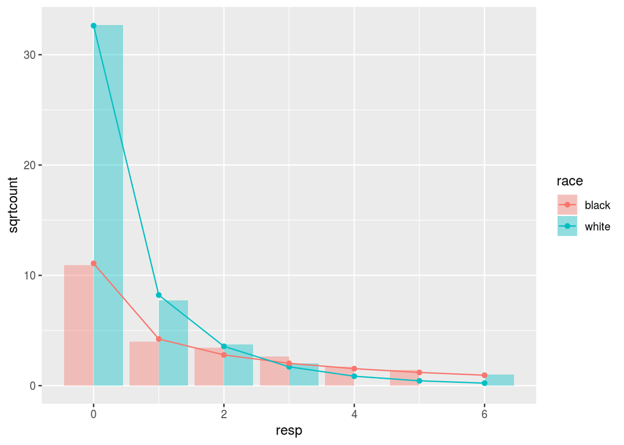

```r
nbinomW <- dnbinom(x = 0:6, size = nbGLM$theta, mu = exp(coef(nbGLM)[1]))* sum(victim$race=="white")
nbinomB <- dnbinom(x = 0:6, size = nbGLM$theta, mu = exp(sum(coef(nbGLM))))* sum(victim$race=="black")
nbinomTidy <- tibble(
  resp=rep(0:6,4),
  obs=factor(rep(c(rep("observed",7),rep("fitted",7)),2)),
  race=factor(c(rep("white",14),rep("black",14))),
  count=c(white,nbinomW,black,nbinomB)) %>%
  mutate(sqrtcount=sqrt(count))
nbinomTidy %>% ggplot(aes(x=resp,y=sqrtcount)) +
  geom_col(data=subset(nbinomTidy, obs=='observed'), aes(fill=race), position = "dodge", alpha=0.4) +
  geom_point(data=subset(nbinomTidy, obs=='fitted'), aes(colour=race)) +
  geom_line(data=subset(nbinomTidy, obs=='fitted'), aes(colour=race))
```